# Cyclistic Bike-Share Analysis

James McBurnie

2025-10-19

# 1. Introduction

Cyclistic is a bike-share company operating across Chicago with a fleet of 5,000+ GPS-tracked bicycles and nearly 700 docking stations. This analysis aims to identify behavioral differences between **annual members** and **casual riders**, providing insights that can guide marketing strategies to increase membership conversion rates.

The dataset spans **September 2024 to September 2025**, sourced from the Divvy open data repository. Data integrity checks confirmed internal consistency and compliance with privacy and licensing standards.

# 2. Data Preparation

The following scripts install the required R packages and load the dataset for analysis.

```r
# Install & load dependencies
library(tidyverse)
library(janitor)
library(lubridate)
library(reactable)
library(skimr)
```

```r
# Custom teal theme for tables
teal_reactable_theme <- reactableTheme(
  backgroundColor = "#FFFFFF",
  color = "#367177",
  stripedColor = "#EAF6F7",
  borderColor = "#43939A",
  highlightColor = "#E8F23855",
  headerStyle = list(background = "#43939A", color = "#FFFFFF", fontWeight = "bold"),
  cellStyle = list(fontSize = "1.03em")
)
```

```r
# Set working directory and load monthly datasets
setwd("C:/Users/James/Desktop/Cyclistic")

file_list <- list.files(pattern = "2024|2025.*divvy-tripdata.csv$")
dataframes <- lapply(file_list, read_csv)

# Check for structural mismatches
compare_df_cols(dataframes, return = "mismatch")
```

| column_name | dataframes_1 | dataframes_2 | dataframes_3 | dataframes_4 | dataframes_5 | dataframes_6 | dataframes_7 | dataframes_8 | dataframes_9 | dataframes_10 | dataframes_11 | dataframes_12 | dataframes_13 |
| --- | --- | --- | --- | --- | --- | --- | --- | --- | --- | --- | --- | --- | --- |

```r
# Combine all monthly CSVs
combined_df <- bind_rows(dataframes)
```

# 3. Data Cleaning

Data cleaning ensures completeness, consistent datatypes, and removal of invalid records. The following steps cover null assessment, duplication checks, categorical harmonization, duration filtering, outlier diagnostics, and geospatial validation.

```r
# Step 1: Assess Null Values
colSums(is.na(combined_df))
```

```
##            ride_id      rideable_type         started_at           ended_at
##                  0                  0                  0                  0
## start_station_name   start_station_id   end_station_name     end_station_id
##            1318179            1318179            1368785            1368785
##          start_lat          start_lng            end_lat            end_lng
##                  0                  0               6195               6195
##      member_casual
##                  0
```

```r
round(sapply(combined_df, function(x) mean(is.na(x))) * 100, 2)
```

```
##            ride_id      rideable_type         started_at           ended_at
##               0.00               0.00               0.00               0.00
## start_station_name   start_station_id   end_station_name     end_station_id
##              20.72              20.72              21.52              21.52
##          start_lat          start_lng            end_lat            end_lng
##               0.00               0.00               0.10               0.10
##      member_casual
##               0.00
```

```r
# Step 2: Remove Duplicates
dupes <- get_dupes(combined_df)
combined_df <- distinct(combined_df)

# Step 3: Standardize Date-Time Fields
combined_df$started_at <- as_datetime(combined_df$started_at)
combined_df$ended_at <- as_datetime(combined_df$ended_at)

# Step 4: Filter Unusable Dates
start_range <- ymd("2024-09-01")
end_range   <- ymd("2025-09-30")
combined_df <- combined_df %>% filter(started_at >= start_range & started_at <= end_range)

# Step 5: Validate and Sanitize Categories
combined_df <- combined_df %>%
  mutate(
    rideable_type = str_to_lower(trimws(rideable_type)),
    member_casual = str_to_lower(trimws(member_casual))
  ) %>%
  mutate(
    member_casual = recode(member_casual, "member" = "Member", "casual" = "Casual"),
    rideable_type = recode(rideable_type, "classic_bike" = "Classic Bike", "electric_bike" = "Electric Bike", "electric_scooter" = "Electric Scooter")
  )

# Step 6: Calculate Trip Durations
combined_df <- combined_df %>%
  mutate(duration = as.numeric(ended_at - started_at)) %>%
  filter(duration >= 60 & duration <= 86400)

# Step 7: Drop Incomplete Data
combined_df <- combined_df %>% remove_empty(which = c("rows", "cols")) %>% drop_na()

# Step 8: Enhance Features - Add Weekday
combined_df <- combined_df %>% mutate(day_of_the_week = weekdays(as.Date(started_at)))

# Step 9: Outlier Detection
find_outliers <- function(x) {
  q1 <- quantile(x, 0.05, na.rm = TRUE)
  q3 <- quantile(x, 0.95, na.rm = TRUE)
  iqr <- q3 - q1
  lower <- q1 - 1.5 * iqr
  upper <- q3 + 1.5 * iqr
  return(x < lower | x > upper)
}

outliers_df <- combined_df %>% filter(find_outliers(duration))

# Step 10: Validate Geographic Accuracy
combined_df <- combined_df %>%
  filter(
    between(start_lat, 41.4, 42.3),
    between(start_lng, -88.3, -87.3),
    between(end_lat, 41.4, 42.3),
    between(end_lng, -88.3, -87.3)
  )

# Step 11: Add Month and Season Columns
combined_df <- combined_df %>%
  mutate(month = lubridate::month(started_at, label = TRUE),
         season = case_when(
           month %in% c("Dec", "Jan", "Feb") ~ "Winter",
           month %in% c("Mar", "Apr", "May") ~ "Spring",
           month %in% c("Jun", "Jul", "Aug") ~ "Summer",
           month %in% c("Sep", "Oct", "Nov") ~ "Fall"
         ))
```

# 4. Analysis

## Executive Insights

Cyclistic’s data shows that members are the backbone of the system, accounting for nearly two-thirds of rides, with classic bikes and short trips driving the largest volumes. Member traffic peaks during the workweek and typical commuting hours, while casual users are most active on weekends and afternoons, indicating leisure-driven behavior. Classic bikes comprise over half of all trips, electric bikes roughly 43%, and scooters less than 2%, reflecting product availability and user preferences. The data demonstrates clear trends in usage by day, hour, duration, and season, all influenced by Chicago’s weather and urban rhythms. To increase annual memberships, marketing should target frequent casual users, promote the cost and convenience of short commutes, and consider referral or loyalty programs.

## User Type Breakdown

```r
combined_df %>%
  count(member_casual) %>%
  mutate(percent = round(100 * n / sum(n), 2)) %>%
  reactable(theme = teal_reactable_theme)
```

| member_casual | n | percent |
| --- | --- | --- |
| Casual | 1549650 | 36.4 |
| Member | 2707738 | 63.6 |

#### Insight

Nearly 64% of all trips are made by members (with 36% by casual riders), confirming the importance of retaining and growing this segment for profitability. Understanding unique user counts and their ride frequency would further inform strategies for expansion.

## Bike Type by User Category

```r
combined_df %>%
  count(rideable_type, member_casual) %>%
  group_by(member_casual) %>%
  mutate(percent = round(100 * n / sum(n), 2)) %>%
  reactable(theme = teal_reactable_theme)
```

| rideable_type | member_casual | n | percent |
| --- | --- | --- | --- |
| Classic Bike | Casual | 835302 | 53.9 |
| Classic Bike | Member | 1540900 | 56.91 |
| Electric Bike | Casual | 689086 | 44.47 |
| Electric Bike | Member | 1145170 | 42.29 |
| Electric Scooter | Casual | 25262 | 1.63 |
| Electric Scooter | Member | 21668 | 0.8 |

#### Insight

Classic bikes account for around 55% of usage in both groups, with electric bikes close behind at 43%. Scooters comprise only 1% of trips, likely a consequence of limited fleet presence rather than demand.

## Trip Duration Summary

```r
combined_df %>%
  group_by(member_casual) %>%
  summarise(
    Min = round(min(duration / 60, na.rm=TRUE),2),
    Q1 = round(quantile(duration / 60, 0.25, na.rm=TRUE),2),
    Median = round(median(duration / 60, na.rm=TRUE),2),
    Mean = round(mean(duration / 60, na.rm=TRUE),2),
    Q3 = round(quantile(duration / 60, 0.75, na.rm=TRUE),2),
    Max = round(max(duration / 60, na.rm=TRUE),2)
  ) %>%
  reactable(theme = teal_reactable_theme)
```

| member_casual | Min | Q1 | Median | Mean | Q3 | Max |
| --- | --- | --- | --- | --- | --- | --- |
| Casual | 1 | 7.36 | 12.96 | 22.59 | 24.31 | 1439.76 |
| Member | 1 | 5.22 | 8.75 | 12.21 | 14.76 | 1438.66 |

## Rides by Day of Week

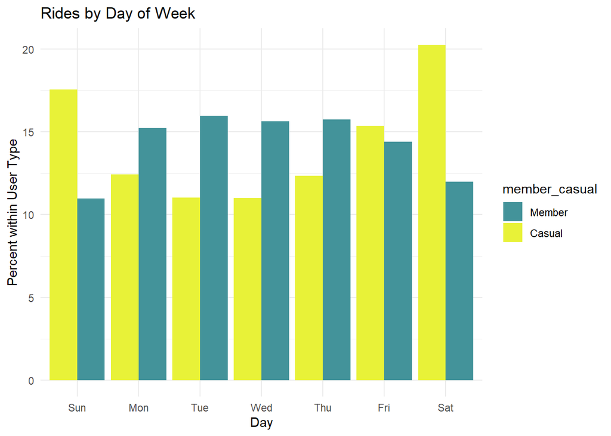

```r
day_df <- combined_df %>%
  mutate(day_of_week = wday(started_at, label = TRUE)) %>%
  count(member_casual, day_of_week) %>%
  group_by(member_casual) %>%
  mutate(percent = 100 * n / sum(n))

ggplot(day_df, aes(x = day_of_week, y = percent, fill = member_casual)) +
  geom_col(position = "dodge") +
  scale_fill_manual(values = c("Member" = "#43939A", "Casual" = "#E8F238")) +
  labs(title = "Rides by Day of Week", x = "Day", y = "Percent within User Type") +
  theme_minimal()
```

#### Insight

Members ride most often on weekdays, whereas casual usage is concentrated from Friday to Sunday, which aligns with patterns of work commutes versus recreational or social outings.

## Rides by Hour of Day

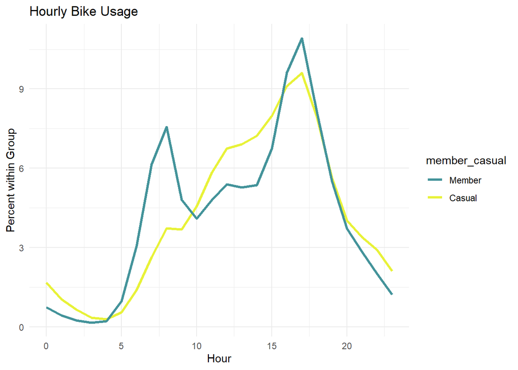

```r
hour_df <- combined_df %>%
  mutate(hour = hour(started_at)) %>%
  count(member_casual, hour) %>%
  group_by(member_casual) %>%
  mutate(percent = 100 * n / sum(n))

ggplot(hour_df, aes(x = hour, y = percent, color = member_casual)) +
  geom_line(size = 1.1) +
  labs(title = "Hourly Bike Usage", x = "Hour", y = "Percent within Group") +
  scale_color_manual(values = c("Member" = "#43939A", "Casual" = "#E8F238")) +
  theme_minimal()
```

#### Insight

Members peak during rush hours (early morning, late afternoon), matching regular commuter schedules. Casual riders show their highest activity during afternoons and weekends, indicating leisurely rides and outings.

## Duration Bucket Analysis

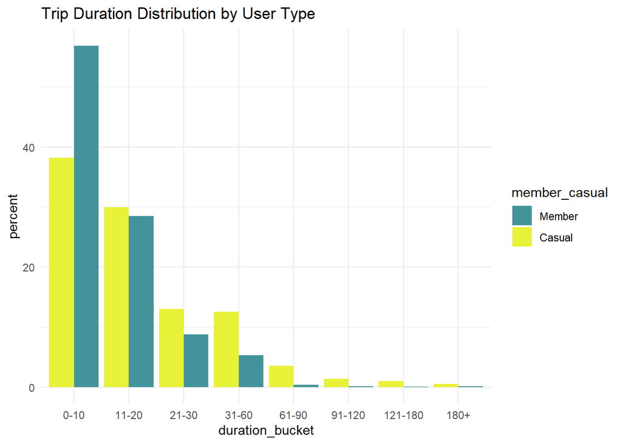

```r
combined_df <- combined_df %>%
  mutate(duration_mins = duration / 60,
         duration_bucket = cut(duration_mins,
            breaks = c(0,10,20,30,60,90,120,180,Inf),
            labels = c("0-10","11-20","21-30","31-60","61-90","91-120","121-180","180+"),
            right=TRUE, include.lowest=TRUE))

duration_summary <- combined_df %>%
  count(member_casual, duration_bucket) %>%
  group_by(member_casual) %>%
  mutate(percent = 100 * n / sum(n))

ggplot(duration_summary, aes(x = duration_bucket, y = percent, fill = member_casual)) +
  geom_col(position = "dodge") +
  scale_fill_manual(values = c("Member" = "#43939A","Casual" = "#E8F238")) +
  labs(title = "Trip Duration Distribution by User Type") +
  theme_minimal()
```

#### Insight

Almost 57% of member rides are brief (under 10 minutes), compared with 38% for casual users. Casual riders favor longer, single-rental journeys. Members display comfort using bikes for quick, spontaneous trips.

## Seasonality by Month

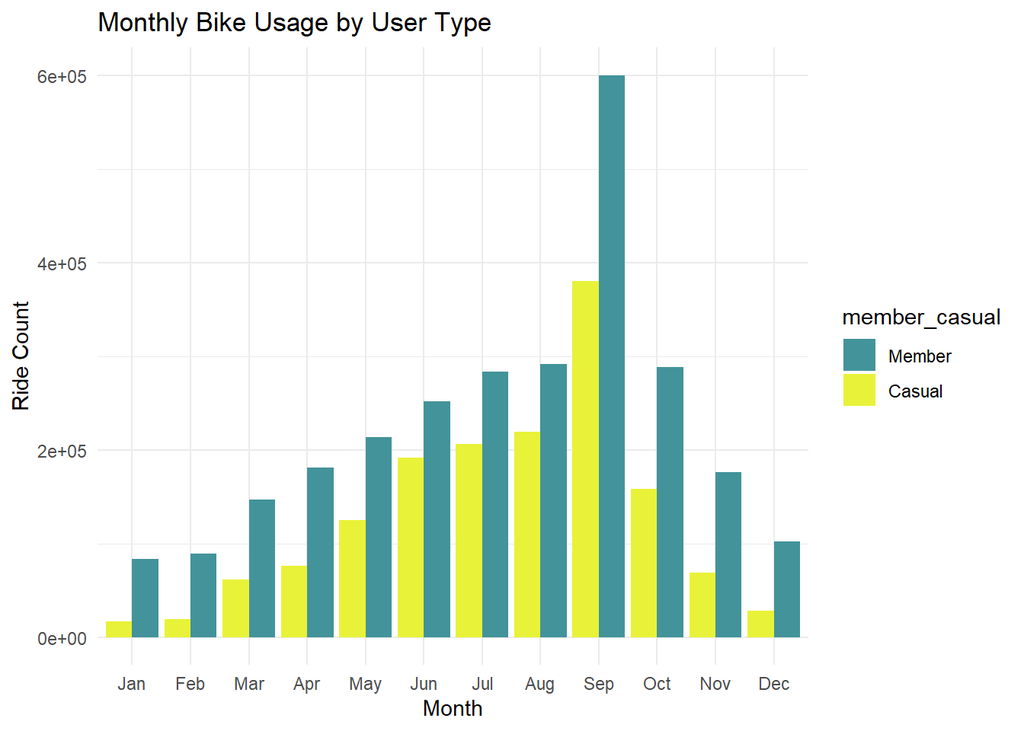

```r
ggplot(combined_df, aes(x = month, fill = member_casual)) +
  geom_bar(position = "dodge") +
  scale_fill_manual(values = c("Member" = "#43939A", "Casual" = "#E8F238")) +
  labs(title = "Monthly Bike Usage by User Type", x = "Month", y = "Ride Count") +
  theme_minimal()
```

#### Insight

Winter months sharply reduce ridership due to adverse weather; peak activity occurs in summer and early fall. September sees a strong spike, worth further review in multi-year trend analysis.

## Most Popular Stations & Top Routes

```r
combined_df %>%
  group_by(start_station_name) %>%
  summarise(rides = n()) %>%
  arrange(desc(rides)) %>%
  slice_head(n = 10) %>%
  reactable(theme = teal_reactable_theme)
```

| start_station_name | rides |
| --- | --- |
| Streeter Dr & Grand Ave | 44179 |
| DuSable Lake Shore Dr & Monroe St | 42016 |
| Kingsbury St & Kinzie St | 40499 |
| Michigan Ave & Oak St | 35636 |
| DuSable Lake Shore Dr & North Blvd | 34818 |
| Clark St & Elm St | 31715 |
| Clinton St & Washington Blvd | 31363 |
| Clinton St & Madison St | 30513 |
| Millennium Park | 30283 |
| Canal St & Madison St | 28978 |

```r
combined_df %>%
  group_by(end_station_name) %>%
  summarise(rides = n()) %>%
  arrange(desc(rides)) %>%
  slice_head(n = 10) %>%
  reactable(theme = teal_reactable_theme)
```

| end_station_name | rides |
| --- | --- |
| Streeter Dr & Grand Ave | 44861 |
| DuSable Lake Shore Dr & Monroe St | 40683 |
| Kingsbury St & Kinzie St | 40305 |
| DuSable Lake Shore Dr & North Blvd | 37405 |
| Michigan Ave & Oak St | 35965 |
| Clark St & Elm St | 31503 |
| Clinton St & Washington Blvd | 31144 |
| Clinton St & Madison St | 30960 |
| Millennium Park | 30923 |
| Theater on the Lake | 29126 |

```r
combined_df %>%
  group_by(start_station_name, end_station_name) %>%
  summarise(rides = n(), .groups = "drop") %>%
  arrange(desc(rides)) %>%
  slice_head(n = 10) %>%
  reactable(theme = teal_reactable_theme)
```

| start_station_name | end_station_name | rides |
| --- | --- | --- |
| DuSable Lake Shore Dr & Monroe St | DuSable Lake Shore Dr & Monroe St | 7437 |
| Streeter Dr & Grand Ave | Streeter Dr & Grand Ave | 6549 |
| Ellis Ave & 60th St | Ellis Ave & 55th St | 5719 |
| Ellis Ave & 55th St | Ellis Ave & 60th St | 5371 |
| Michigan Ave & Oak St | Michigan Ave & Oak St | 4942 |
| Ellis Ave & 60th St | University Ave & 57th St | 4769 |
| University Ave & 57th St | Ellis Ave & 60th St | 4646 |
| Navy Pier | Navy Pier | 4180 |
| DuSable Lake Shore Dr & Monroe St | Streeter Dr & Grand Ave | 4123 |
| Calumet Ave & 33rd St | State St & 33rd St | 3798 |

#### Insight

The busiest stations and most popular routes reflect Chicago’s downtown commuting flow and recreational hotspots. Optimizing fleet availability at these nodes can enhance user experience.

## Recommendations

Cyclistic should highlight the value and convenience of short trips for members, position bike share as an everyday urban transport solution, and implement referral and loyalty programs to convert casual users. Quantifying member savings versus pay-as-you-go options could drive subscription growth, especially among frequent casual riders.

# 5. Conclusions & Recommendations

Converting casual users into members remains a challenge, but this analysis highlights actionable strategies.  
- Promote short-trip utility and last-mile convenience in summer campaigns.  
- Offer referral rewards to encourage social adoption.  
- Maintain engagement during winter via credits or partner offers.  
- Use quantitative savings analyses to illustrate membership value.

# Appendix